# Travel Package Purchase Prediction

#### Hyperparameter Tuning

```python
# Choose the type of classifier.
bagging_estimator_tuned = BaggingClassifier(random_state=1)

# Grid of parameters to choose from
parameters = {'max_samples': [0.7,0.8,0.9,1],
              'max_features': [0.7,0.8,0.9,1],
              'n_estimators' : [10,20,30,40,50],
             }

# Type of scoring used to compare parameter combinations
scorer = metrics.make_scorer(metrics.f1_score)

# Run the grid search
grid_obj = GridSearchCV(bagging_estimator_tuned, parameters, scoring=scorer,cv=5)
grid_obj = grid_obj.fit(X_train, y_train)

# Set the clf to the best combination of parameters
bagging_estimator_tuned = grid_obj.best_estimator_

# Fit the best algorithm to the data.
bagging_estimator_tuned.fit(X_train, y_train)
```

```
BaggingClassifier(max_features=0.9, max_samples=0.9, n_estimators=50,
                  random_state=1)
```

```
   Accuracy    Recall  Precision        F1
0  0.999415  0.996894        1.0  0.998445
   Accuracy    Recall  Precision       F1
0  0.904567  0.568841   0.882022  0.69163
```

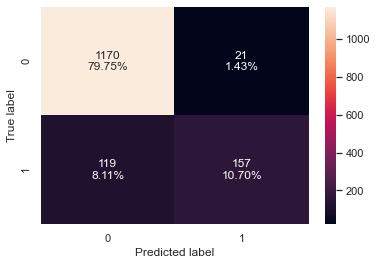

```python
#Calculating different metrics
bagging_estimator_tuned_model_train_perf=model_performance_classification_sklearn(bagging_estimator_tuned,X_train,y_train)
print(bagging_estimator_tuned_model_train_perf)
bagging_estimator_tuned_model_test_perf=model_performance_classification_sklearn(bagging_estimator_tuned,X_test,y_test)
print(bagging_estimator_tuned_model_test_perf)

#Creating confusion matrix
confusion_matrix_sklearn(bagging_estimator_tuned,X_test,y_test)
```

**Observations:**

- Hyper tuning has a better accuracy metric and the F1 score is also higher.
- Bagging classifier is overfitting the training data.
- Let's try Random Forest Classifiers and see if the model performance improves.

### Random Forest Classifier

```
Training performance:
    Accuracy  Recall  Precision   F1
0       1.0     1.0        1.0  1.0
Testing performance:
    Accuracy    Recall  Precision        F1
0  0.884799  0.449275   0.879433  0.594724
```

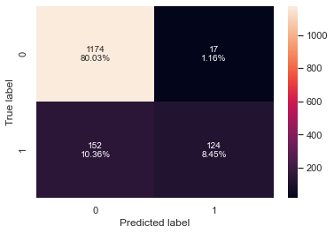

```python
#Fitting the model
rf_estimator = RandomForestClassifier(random_state=1)
rf_estimator.fit(X_train,y_train)

#Calculating different metrics
rf_estimator_model_train_perf=model_performance_classification_sklearn(rf_estimator,X_train,y_train)
print("Training performance:\n",rf_estimator_model_train_perf)
rf_estimator_model_test_perf=model_performance_classification_sklearn(rf_estimator,X_test,y_test)
print("Testing performance:\n",rf_estimator_model_test_perf)

#Creating confusion matrix
confusion_matrix_sklearn(rf_estimator,X_test,y_test)
```

**Observations:**

- Random Forest classifier is also overfitting for the training set.
- F1 score metric also reduced.
- Let's try hyperparameter tuning and see if the model performance improves.

#### Hyperparameter Tuning

```python
# Choose the type of classifier.
rf_tuned = RandomForestClassifier(class_weight={0:0.15,1:0.85},random_state=29)

parameters = {"n_estimators": np.arange(10,60,5),
              'criterion':['gini','entropy'],
            "min_samples_leaf": np.arange(5,11,1),
            "max_features":['sqrt','log2'],
            "max_samples": np.arange(0.5, 1, 0.1),
             }

# Type of scoring used to compare parameter combinations
scorer = metrics.make_scorer(metrics.f1_score)

# Run the grid search
grid_obj = GridSearchCV(rf_tuned, parameters, scoring=scorer,cv=5)
grid_obj = grid_obj.fit(X_train, y_train)

# Set the clf to the best combination of parameters
rf_tuned = grid_obj.best_estimator_

# Fit the best algorithm to the data.
rf_tuned.fit(X_train, y_train)
```

```
RandomForestClassifier(class_weight={0: 0.15, 1: 0.85}, max_features='sqrt',
                       max_samples=0.8999999999999999, min_samples_leaf=5,
                       n_estimators=35, random_state=29)
```

```
Training performance:
    Accuracy    Recall  Precision        F1
0  0.905583  0.939441    0.68054  0.789302
Testing performance:
    Accuracy    Recall  Precision        F1
0  0.838446  0.677536   0.558209  0.612111
```

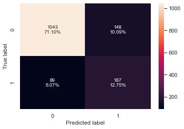

```python
#Calculating different metrics
rf_tuned_model_train_perf=model_performance_classification_sklearn(rf_tuned,X_train,y_train)
print("Training performance:\n",rf_tuned_model_train_perf)
rf_tuned_model_test_perf=model_performance_classification_sklearn(rf_tuned,X_test,y_test)
print("Testing performance:\n",rf_tuned_model_test_perf)

#Creating confusion matrix
confusion_matrix_sklearn(rf_tuned,X_test,y_test)
```

**Observations:**

- The overall model performance metric has increased after Hypertuning, but it looks like its still overfitting the training data set.
- Let's try boosting models

## Boosting Models

### AdaBoost Classifier

```
   Accuracy  Recall  Precision        F1
0  0.835136    0.25   0.665289  0.363431
   Accuracy    Recall  Precision        F1
0  0.843899  0.278986   0.719626  0.402089
```

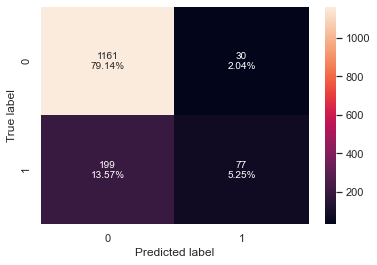

```python
#Fitting the model
ab_classifier = AdaBoostClassifier(random_state=1)
ab_classifier.fit(X_train,y_train)

#Calculating different metrics
ab_classifier_model_train_perf=model_performance_classification_sklearn(ab_classifier,X_train,y_train)
print(ab_classifier_model_train_perf)
ab_classifier_model_test_perf=model_performance_classification_sklearn(ab_classifier,X_test,y_test)
print(ab_classifier_model_test_perf)

#Creating confusion matrix
confusion_matrix_sklearn(ab_classifier,X_test,y_test)
```

**Observation:**

- Adaboost is giving more generalized performance than previous models but the test f1-score is too low.
- Let's try hyperparameter tuning and see if the model performance improves.

### Hyperparameter Tuning

```python
# Choose the type of classifier.
abc_tuned = AdaBoostClassifier(random_state=1)

# Grid of parameters to choose from
parameters = {
    #Let's try different max_depth for base_estimator
    "base_estimator":[DecisionTreeClassifier(max_depth=1),DecisionTreeClassifier(max_depth=2),
                      DecisionTreeClassifier(max_depth=3)],
    "n_estimators": np.arange(10,110,10),
    "learning_rate":np.arange(0.1,2,0.1)
}

# Type of scoring used to compare parameter  combinations
scorer = metrics.make_scorer(metrics.f1_score)

# Run the grid search
grid_obj = GridSearchCV(abc_tuned, parameters, scoring=scorer,cv=5)
grid_obj = grid_obj.fit(X_train, y_train)

# Set the clf to the best combination of parameters
abc_tuned = grid_obj.best_estimator_

# Fit the best algorithm to the data.
abc_tuned.fit(X_train, y_train)
```

```
AdaBoostClassifier(base_estimator=DecisionTreeClassifier(max_depth=3),
                   learning_rate=1.1, n_estimators=100, random_state=1)
```

```
   Accuracy    Recall  Precision        F1
0  0.978077  0.913043   0.968699  0.940048
   Accuracy    Recall  Precision        F1
0  0.870484  0.557971   0.693694  0.618474
```

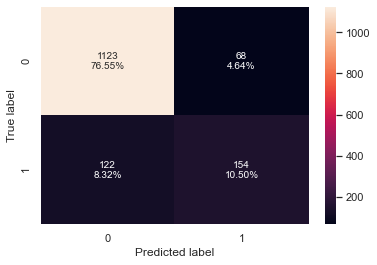

```python
#Calculating different metrics
abc_tuned_model_train_perf=model_performance_classification_sklearn(abc_tuned,X_train,y_train)
print(abc_tuned_model_train_perf)
abc_tuned_model_test_perf=model_performance_classification_sklearn(abc_tuned,X_test,y_test)
print(abc_tuned_model_test_perf)

#Creating confusion matrix
confusion_matrix_sklearn(abc_tuned,X_test,y_test)
```

**Observations:**

### Gradient Boosting Classifier

```
Training performance:
    Accuracy   Recall  Precision        F1
0   0.87869  0.43323   0.848024  0.573484
Testing performance:
    Accuracy    Recall  Precision        F1
0  0.871166  0.369565   0.871795  0.519084
```

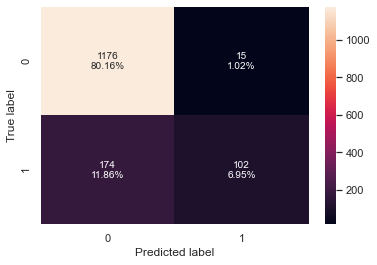

```python
#Fitting the model
gb_classifier = GradientBoostingClassifier(random_state=1)
gb_classifier.fit(X_train,y_train)

#Calculating different metrics
gb_classifier_model_train_perf=model_performance_classification_sklearn(gb_classifier,X_train,y_train)
print("Training performance:\n",gb_classifier_model_train_perf)
gb_classifier_model_test_perf=model_performance_classification_sklearn(gb_classifier,X_test,y_test)
print("Testing performance:\n",gb_classifier_model_test_perf)

#Creating confusion matrix
confusion_matrix_sklearn(gb_classifier,X_test,y_test)
```

**Observations:**

- The metrics are comparable and close for both train and test set and the F1Score metric has increased by compare with AdaBoost Classifier.

#### Hyperparameter Tuning

```python
# Choose the type of classifier.
gbc_tuned = GradientBoostingClassifier(init=AdaBoostClassifier(random_state=1),random_state=1)

# Grid of parameters to choose from
parameters = {
    "n_estimators": [100,150,200,250],
    "subsample":[0.8,0.9,1],
    "max_features":[0.7,0.8,0.9,1]
}

# Type of scoring used to compare parameter combinations
scorer = metrics.make_scorer(metrics.f1_score)

# Run the grid search
grid_obj = GridSearchCV(gbc_tuned, parameters, scoring=scorer,cv=5)
grid_obj = grid_obj.fit(X_train, y_train)

# Set the clf to the best combination of parameters
gbc_tuned = grid_obj.best_estimator_

# Fit the best algorithm to the data.
gbc_tuned.fit(X_train, y_train)
```

```
GradientBoostingClassifier(init=AdaBoostClassifier(random_state=1),
                           max_features=0.8, n_estimators=250, random_state=1,
                           subsample=0.9)
```

```
Training performance:
    Accuracy    Recall  Precision        F1
0  0.912014  0.586957   0.915254  0.715232
Testing performance:
    Accuracy    Recall  Precision        F1
0  0.873892  0.416667   0.827338  0.554217
```

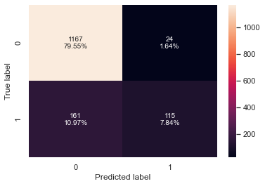

```python
#Calculating different metrics
gbc_tuned_model_train_perf=model_performance_classification_sklearn(gbc_tuned,X_train,y_train)
print("Training performance:\n",gbc_tuned_model_train_perf)
gbc_tuned_model_test_perf=model_performance_classification_sklearn(gbc_tuned,X_test,y_test)
print("Testing performance:\n",gbc_tuned_model_test_perf)

#Creating confusion matrix
confusion_matrix_sklearn(gbc_tuned,X_test,y_test)
```

**Observations:**

- F1-Score has increased but the model has started to overfit the training data
- Let's try Stacking Classifier

```python
estimators = [('Random Forest',rf_tuned), ('Gradient Boosting',gbc_tuned), ('Decision Tree',dtree_estimator)]

final_estimator = abc_tuned

stacking_classifier= StackingClassifier(estimators=estimators,final_estimator=final_estimator)

stacking_classifier.fit(X_train,y_train)
```

[output not shown]

```
Training performance:
    Accuracy    Recall  Precision        F1
0  0.932768  0.826087   0.818462  0.822257
Testing performance:
    Accuracy    Recall  Precision       F1
0  0.845944  0.547101   0.599206  0.57197
```

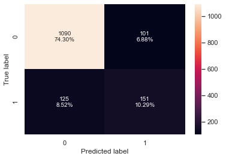

```python
#Calculating different metrics
stacking_classifier_model_train_perf=model_performance_classification_sklearn(stacking_classifier,X_train,y_train)
print("Training performance:\n",stacking_classifier_model_train_perf)
stacking_classifier_model_test_perf=model_performance_classification_sklearn(stacking_classifier,X_test,y_test)
print("Testing performance:\n",stacking_classifier_model_test_perf)

#Creating confusion matrix
confusion_matrix_sklearn(stacking_classifier,X_test,y_test)
```

**Observations:**

- F1-Score has increased but the model has started to overfit the training data

### Comparing all models

```python
# training performance comparison

models_train_comp_df = pd.concat(
    [d_tree_model_train_perf.T,dtree_estimator_model_train_perf.T,rf_estimator_model_train_perf.T,rf_tuned_model_train_perf.T,
     bagging_classifier_model_train_perf.T,bagging_estimator_tuned_model_train_perf.T,ab_classifier_model_train_perf.T,
     abc_tuned_model_train_perf.T,gb_classifier_model_train_perf.T,gbc_tuned_model_train_perf.T,stacking_classifier_model_train_perf.T],
    axis=1,
)
models_train_comp_df.columns = [
    "Decision Tree",
    "Decision Tree Estimator",
    "Random Forest Estimator",
    "Random Forest Tuned",
    "Bagging Classifier",
    "Bagging Estimator Tuned",
    "Adaboost Classifier",
    "Adabosst Classifier Tuned",
    "Gradient Boost Classifier",
    "Gradient Boost Classifier Tuned",
    "Stacking Classifier"]
print("Training performance comparison:")
models_train_comp_df
```

```
Training performance comparison:
```

|  | Decision Tree | Decision Tree Estimator | Random Forest Estimator | Random Forest Tuned | Bagging Classifier | Bagging Estimator Tuned | Adaboost Classifier | Adabosst Classifier Tuned | Gradient Boost Classifier | Gradient Boost Classifier Tuned | Stacking Classifier |
| --- | --- | --- | --- | --- | --- | --- | --- | --- | --- | --- | --- |
| Accuracy | 1.0 | 1.0 | 1.0 | 0.905583 | 0.989769 | 0.999415 | 0.835136 | 0.978077 | 0.878690 | 0.912014 | 0.932768 |
| Recall | 1.0 | 1.0 | 1.0 | 0.939441 | 0.947205 | 0.996894 | 0.250000 | 0.913043 | 0.433230 | 0.586957 | 0.826087 |
| Precision | 1.0 | 1.0 | 1.0 | 0.680540 | 0.998363 | 1.000000 | 0.665289 | 0.968699 | 0.848024 | 0.915254 | 0.818462 |
| F1 | 1.0 | 1.0 | 1.0 | 0.789302 | 0.972112 | 0.998445 | 0.363431 | 0.940048 | 0.573484 | 0.715232 | 0.822257 |

```python
# testing performance comparison

models_test_comp_df = pd.concat(
    [d_tree_model_test_perf.T,dtree_estimator_model_test_perf.T,rf_estimator_model_test_perf.T,rf_tuned_model_test_perf.T,
     bagging_classifier_model_test_perf.T,bagging_estimator_tuned_model_test_perf.T,ab_classifier_model_test_perf.T,
     abc_tuned_model_test_perf.T,gb_classifier_model_test_perf.T,gbc_tuned_model_test_perf.T,stacking_classifier_model_test_perf.T],
    axis=1,
)
models_test_comp_df.columns = [
    "Decision Tree",
    "Decision Tree Estimator",
    "Random Forest Estimator",
    "Random Forest Tuned",
    "Bagging Classifier",
    "Bagging Estimator Tuned",
    "Adaboost Classifier",
    "Adabosst Classifier Tuned",
    "Gradient Boost Classifier",
    "Gradient Boost Classifier Tuned",
    "Stacking Classifier"]
print("Testing performance comparison:")
models_test_comp_df
```

```
Testing performance comparison:
```

|  | Decision Tree | Decision Tree Estimator | Random Forest Estimator | Random Forest Tuned | Bagging Classifier | Bagging Estimator Tuned | Adaboost Classifier | Adabosst Classifier Tuned | Gradient Boost Classifier | Gradient Boost Classifier Tuned | Stacking Classifier |
| --- | --- | --- | --- | --- | --- | --- | --- | --- | --- | --- | --- |
| Accuracy | 0.852079 | 0.852079 | 0.884799 | 0.838446 | 0.888889 | 0.904567 | 0.843899 | 0.870484 | 0.871166 | 0.873892 | 0.845944 |
| Recall | 0.601449 | 0.601449 | 0.449275 | 0.677536 | 0.536232 | 0.568841 | 0.278986 | 0.557971 | 0.369565 | 0.416667 | 0.547101 |
| Precision | 0.608059 | 0.608059 | 0.879433 | 0.558209 | 0.808743 | 0.882022 | 0.719626 | 0.693694 | 0.871795 | 0.827338 | 0.599206 |
| F1 | 0.604736 | 0.604736 | 0.594724 | 0.612111 | 0.644880 | 0.691630 | 0.402089 | 0.618474 | 0.519084 | 0.554217 | 0.571970 |

**Observations:**

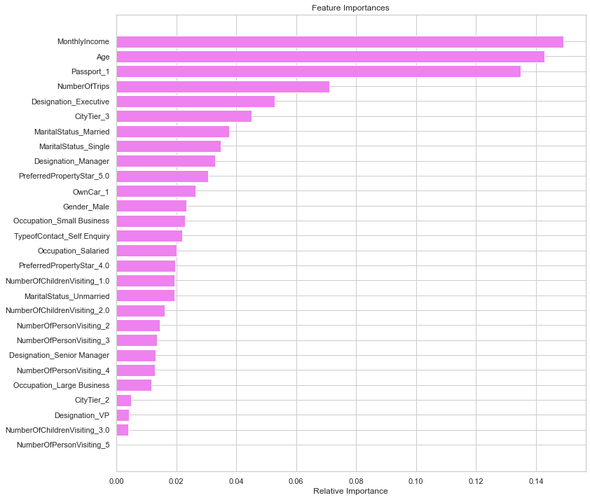

```python
feature_names = X_train.columns
importances = rf_tuned.feature_importances_
indices = np.argsort(importances)

plt.figure(figsize=(12,12))
plt.title('Feature Importances')
plt.barh(range(len(indices)), importances[indices], color='violet', align='center')
plt.yticks(range(len(indices)), [feature_names[i] for i in indices])
plt.xlabel('Relative Importance')
plt.show()
```

**Observation:**

### Recommendations:

- Age, MonthlyIncome and Passport are most important features for the prediction so the business can target customers with passport, higher age and higher monthly income customers.
- Average DurationofPitch is 3. Longer pitch duration doesnt effective on the product purchase. We should keep this in mind and plan the future presentations.
- Basic and Deluxe are the most popular packages. We can increase other package sales by marketing for example first class, second class and third class so we can attract all category customers.
- There was imbalance in data, only 18% of customers bought any product. This must be fixed for future analysis.
- NumberofChilden and NumberofPeoplevisiting doesnt have great impact on the prediction
- Since Single customers are buying product higher, the business can provide offers for married people to attract customers
- For customers whose NumberOfTrips is higher we can provide them some credit points/cash back to redeem for the future buy so that customers stick with us